# Global Gender Stats

*Data Source: World Bank, United Nations Gender Statistics*

Contents:  
I. General Distribution of Dataset  
a. Distribution of female managers  
b. Distribution of male managers  
II. Correlation Matrix  
III. Regression Analysis  
a. Simple regression for proportion of female managers  
b. Simple regression for proportion of male managers  
c. Multiple regression for all variables in the dataset

## I. General Distribution of Dataset

#### a. Distribution of female managers

```r
summary(gender_stats_1)
```

```
    region            country               year        labor_pop          w_ind_porp
 Length:78          Length:78          Min.   :2005   Min.   :  174291   Min.   : 3.870
 Class :character   Class :character   1st Qu.:2010   1st Qu.: 2197518   1st Qu.: 9.473
 Mode  :character   Mode  :character   Median :2011   Median : 4447240   Median :12.720
                                       Mean   :2011   Mean   : 9598832   Mean   :13.471
                                       3rd Qu.:2012   3rd Qu.:11252092   3rd Qu.:16.465
                                       Max.   :2012   Max.   :53682338   Max.   :25.280
  w_serv_porp      w_agr_prop      w_ind_count       w_serv_count       w_agr_count
 Min.   :34.33   Min.   : 0.210   Min.   :   9878   Min.   :  150030   Min.   :  156232
 1st Qu.:73.61   1st Qu.: 1.798   1st Qu.: 240411   1st Qu.: 1945762   1st Qu.: 1954594
 Median :83.09   Median : 2.820   Median : 495790   Median : 3515831   Median : 3543128
 Mean   :78.76   Mean   : 7.141   Mean   :1329211   Mean   : 7475608   Mean   : 7738015
 3rd Qu.:87.96   3rd Qu.: 7.772   3rd Qu.:1813316   3rd Qu.: 9830912   3rd Qu.: 9939624
 Max.   :93.20   Max.   :54.150   Max.   :8454968   Max.   :42650618   Max.   :43227606
     w_mgr           m_mgr         female_ed        male_ed           diff
 Min.   :14.32   Min.   :44.19   Min.   : 0.00   Min.   : 0.00   Min.   :-16.200
 1st Qu.:27.06   1st Qu.:64.45   1st Qu.:14.43   1st Qu.:15.04   1st Qu.: -2.208
 Median :31.27   Median :68.73   Median :23.77   Median :20.83   Median :  0.520
 Mean   :31.29   Mean   :68.71   Mean   :23.00   Mean   :22.18   Mean   :  0.825
 3rd Qu.:35.55   3rd Qu.:72.94   3rd Qu.:31.15   3rd Qu.:29.02   3rd Qu.:  4.820
 Max.   :55.81   Max.   :85.68   Max.   :52.94   Max.   :46.79   Max.   : 14.500
     cat              dumregion
 Length:78          Min.   :0.0000
 Class :character   1st Qu.:1.0000
 Mode  :character   Median :1.0000
                    Mean   :0.7821
                    3rd Qu.:1.0000
                    Max.   :1.0000
```

```r
mean(gender_stats_1$w_mgr)
```

```
[1] 31.29295
```

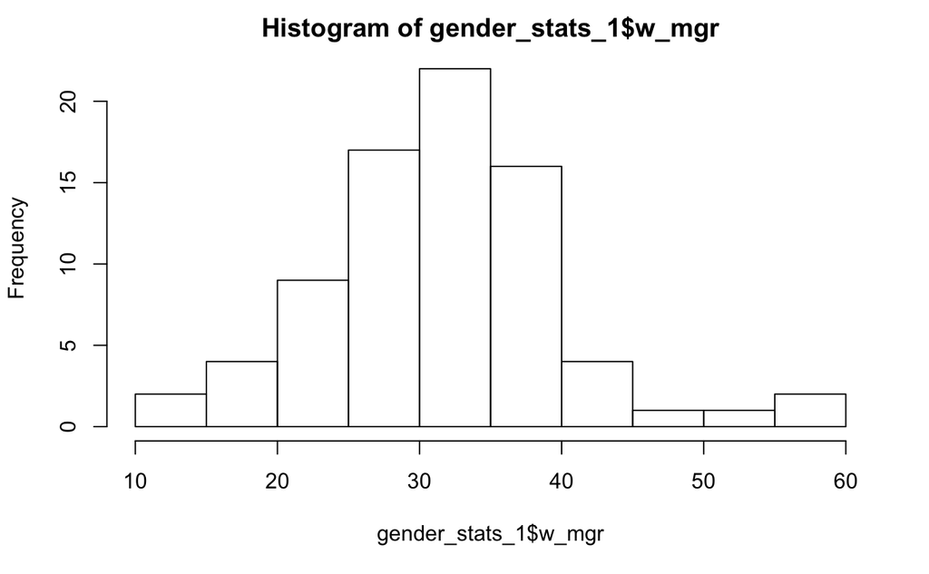

```r
hist(gender_stats_1$w_mgr)
```

> Proportion of female managers average 31.3% across all regions and all years in the dataset. Distribution is normal.

#### b. Distribution of male managers

```r
mean(gender_stats_1$m_mgr)
```

```
[1] 68.70705
```

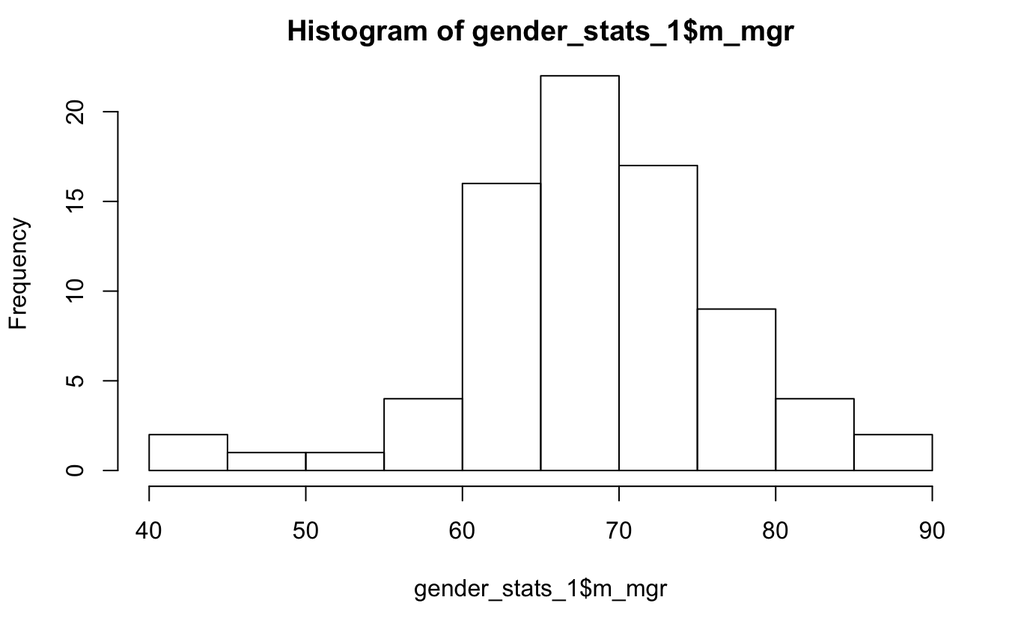

```r
hist(gender_stats_1$m_mgr)
```

> Proportion of male managers average 68.7% across all regions and all years in the dataset. Distribution is normal.

```r
library(dplyr)
gender_ce <- select(gender_stats_1, -country, -region,  -cat)
```

## II. Correlation Matrix

```r
corrmatrix <- cor(gender_ce, use="complete.obs")
View(corrmatrix)
```

[figure not shown]